### The proposal function

The function `q()` returns 2 types of values depending on the argument, `type=`. If

`type=="draw"`

then the function returns a random draw from the gamma distribution with a mean centered on `mu` and a standard deviation equal to the tuning parameter. When we use the function in this way, we make `mu`= the current value in the chain . If

`type=="density"`

then the function returns the density of theta, which allows us to give the function the value of the proposal or the current value in the chain. Take a look at how the function is called and think about the relationship between the function call and the function definition.

```r
#Proposal function
q=function(theta,mu,tune, type){
    sigma=tune
    if (type == "density") return (dgamma(theta,mu^2/sigma^2, mu/sigma^2))
    if (type == "draw") return (rgamma(1,mu^2/sigma^2, mu/sigma^2))
}
```

### The prior function

The prior function provides flat, uniform priors on all of the parameters, returning probability densities on the log scale. You could make them informative by using the proper distribution and arguments. You could also choose other non-informative priors if you like by changing the distributions.

```r
#Function for priors.  Note that the densities are returned on the log scale.
prior=function(param,theta){
    if(param == "alpha") return( dunif(theta, min=0, max=500, log=TRUE))
    if(param=="c") return(dunif(theta,min = 0, max = 200, log=TRUE))
    if(param=="gamma") return(dunif(theta,min=0,max=200,log=TRUE))
    if(param=="sigma" ) return(dunif(theta,min=0,max=200, log=TRUE))
    }
```

### The likeliood function

The likelihood function should resemble the one your wrote for the Bayes theorem lab. These should be getting quite familiar by now. There few things worth noting– you will need to modify this function if you want to use likelihood functions other than the normal, which will probably require the proper moment matching. Note the trick for preventing errors from infinite values, which can arise when a proposal produces a likelihood that is infinite or NaN. This can happen. The function returns the log probability density of the ouput of the model conditional on all of the data.

```r
#Likelihood function
Like=function(y,L,alpha,gamma,c ,sigma){
    mu=g(alpha=alpha, gamma=gamma,c=c, L=L)
    LogL = dnorm(y, mean=mu, sd=sigma, log=TRUE)
    return(sum(LogL[is.finite(LogL)]))
    }
```

### The choose function

The choose function calculates the ratio of the posterior draw for the current value and the proposed one and decides which one to keep using the algorithm we saw in lecture. Note expoentiating the difference between the logs of the likelihoods multiplied by the priors. Why is this a good idea rather than using the unlogged ratio?

```r
#Function to choose current or proposed value
choose=function(x, z, Like_z, Like_x, param, tune){
    numerator = Like_z + prior(param,theta=z)  # these are both logs so we add rather than multiply
    denominator = Like_x + prior(param,theta=x)
    q.ratio = q(theta=x,mu=z,tune=tune, type="density") / q(theta=z,mu=x,tune=tune, type="density")
    R =  exp(numerator - denominator) * q.ratio #because these are logs, we exponetiate the difference to ge the ratio.
    if(R > runif(1,min=0,max=1)) new =z
    else new = x
        return(new)
}
```

Using the parameter `gamma` to illustrate, we call the `choose` function using `choose(x=x$gamma[i-1], z=z, Like_z=Like_z, Like_x=Like_x, param="gamma", tune=tune$gamma` Discuss where these argumenta come from with you colleagues.

### A plotting function

To make life easier….

```r
do_plots=function(data, x, n.iter, burnin){

    #trace plots
    par(mfrow=c(2,2))
    plot(x$gamma,typ="l", xlab="Iteration"); abline(h=mean(x$gamma[burnin:n.iter]),col="red")
    plot(x$alpha,typ="l",, xlab="Iteration");abline(h = mean(x$alpha[burnin:n.iter]), col="red")
    plot(x$c,typ="l",, xlab="Iteration");abline(h = mean(x$c[burnin:n.iter]), col="red")
    plot(x$sigma,typ="l", xlab="Iteration"); abline(h=mean(x$sigma[burnin:n.iter]), col="red")

    par(mfrow=c(1,1))
    q.y.hat=apply(x$y.hat[,burnin:n.iter,1],1, function(x) quantile(x, c(.025,.5,.975)))
    plot(data$x,data$y,xlab="Light level", ylab="Growth rate", main="Prediction of growth rate")
    lines(data$x,q.y.hat[2,], col="orange", lwd="4")
    lines(data$x,q.y.hat[1,], lty = "dashed", col="orange" )
    lines(data$x,q.y.hat[3,], lty = "dashed", col="orange" )
    lines(data$x, g(alpha=data$nls.alpha, gamma=data$nls.gamma, c=data$nls.c, L=data$x), col="blue")
    legend(40,18, c("Median", "2.5% quantile", "97.5% quantile", "nlsfit"), lty=c("solid", "dashed", "dashed"),col=c("orange", "orange", "orange", "blue"),bty="n")


plot_density = function(p,v1,v2, param, burnin, n.iter){
    hist(p[burnin:n.iter],breaks=100, xlab="Value of parameter", freq=FALSE, main=param)
    abline(v=v1,col="red", lwd=2)
    abline(v=v2, col="blue", lwd=2)
    abline(v=median(p[burnin:n.iter]), col="orange", lwd=2)
}

par(mfrow=c(2,2))
plot_density(p=x$alpha,v1=data$gen.alpha, v2=data$nls.alpha, param=expression(alpha), burnin=burnin, n.iter=n.iter)
plot_density(p=x$gamma,v1=data$gen.gamma, v2=data$nls.gamma, param=expression(gamma), burnin=burnin, n.iter=n.iter)
plot_density(p=x$c,v1=data$gen.c, v2=data$nls.c, param=expression(c), burnin=burnin, n.iter=n.iter)
plot_density(p=x$sigma,v1=data$gen.sigma, v2=data$nls.sigma, param=expression(sigma), burnin=burnin, n.iter=n.iter)

} #end of plotting function
```

#### VI. Problem

A good way to work when writing algorithms like this one is to treat parameters as known (you know them because you used them to simulate the data), adding one unknown at a time.Y So you might usefully start by wrting blocks of code like the one for alpha, but use fixed arguments for the other unknowns. Then “unfix” say, $\gamma$ leaving the others fixed. Get that working. Then “unfix” $\c$ etc.

Your asnswer should resemble the following:

```r
#Execute the function definitions.
source("Gibbs MH functions.R")
#Simulate data to resemble data use in likelihood lab
data=get_data(alpha=38.5, gamma=1.7, sigma=2, c=8)
```

[figure not shown]

```r
n.iter=50000
x=setup(n.iter=n.iter,n.chain=1, parameter.names=c("alpha","c","gamma","sigma", "y.hat","growth_ratio"), dim.x=c(1,1,1,1,50,1))
tune=x$tune
  for( i in 2:n.iter){
    if(i%%1000==0) cat(i,"\n");flush.console() #iteration counter, prints every 1000th i
    #Update alpha
    #z = proposal(mu=x$alpha[i-1],tune=tune$alpha)
    z=q(mu=x$alpha[i-1],tune=tune$alpha, type="draw")
    Like_z = Like(y=data$y, L=data$x, alpha=z, c=x$c[i-1], gamma=x$gamma[i-1], sigma=x$sigma[i-1])
    Like_x = Like(y=data$y, L=data$x, alpha=x$alpha[i-1], c=x$c[i-1], gamma=x$gamma[i-1], sigma=x$sigma[i-1])
    x$alpha[i] =choose(x=x$alpha[i-1], z=z, Like_z=Like_z, Like_x=Like_x, param="alpha", tune=tune$alpha)

    # # #Update gamma
    #z = proposal(mu=x$gamma[i-1],tune=tune$gamma)
    z = q(mu=x$gamma[i-1],tune=tune$gamma, type="draw")
    Like_z = Like(y=data$y, L=data$x, alpha=x$alpha[i], c=x$c[i-1], gamma=z, sigma=x$sigma[i-1])
    Like_x = Like(y=data$y, L=data$x, alpha=x$alpha[i], c=x$c[i-1], gamma=x$gamma[i-1], sigma=x$sigma[i-1])
    x$gamma[i] =choose(x=x$gamma[i-1], z=z, Like_z=Like_z, Like_x=Like_x, param="gamma", tune=tune$gamma)

    # # #Update c
    #z = proposal(mu=x$c[i-1],tune=tune$c)
    z = q(mu=x$c[i-1],tune=tune$c, type="draw")
    Like_z = Like(y=data$y, L=data$x, alpha=x$alpha[i], c=z, gamma=x$gamma[i], sigma=x$sigma[i-1])
    Like_x = Like(y=data$y, L=data$x, alpha=x$alpha[i], c=x$c[i-1], gamma=x$gamma[i], sigma=x$sigma[i-1])
    x$c[i] =choose(x=x$c[i-1], z=z, Like_z=Like_z, Like_x=Like_x, param="c", tune=tune$c)

    # # #Update sigma
    #z = proposal(mu=x$sigma,tune=tune$sigma)
    z = q(mu=x$sigma[i-1],tune=tune$sigma, type="draw")
    Like_z = Like(y=data$y, L=data$x, alpha=x$alpha[i], c=x$c[i], gamma=x$gamma[i], sigma=z)
    Like_x = Like(y=data$y, L=data$x, alpha=x$alpha[i], c=x$c[i], gamma=x$gamma[i], sigma=x$sigma[i-1])
    x$sigma[i] =choose(x=x$sigma[i-1], z=z, Like_z=Like_z, Like_x=Like_x, param="sigma", tune=tune$sigma)

    #estimate derived quantities
    x$y.hat[,i,1] = g(alpha=x$alpha[i],gamma=x$gamma[i],c=x$c[i],L=data$x)
    x$growth.ratio[i]= x$alpha[i] / x$gamma[i]
  } #end of iteration loop
```

[output not shown]

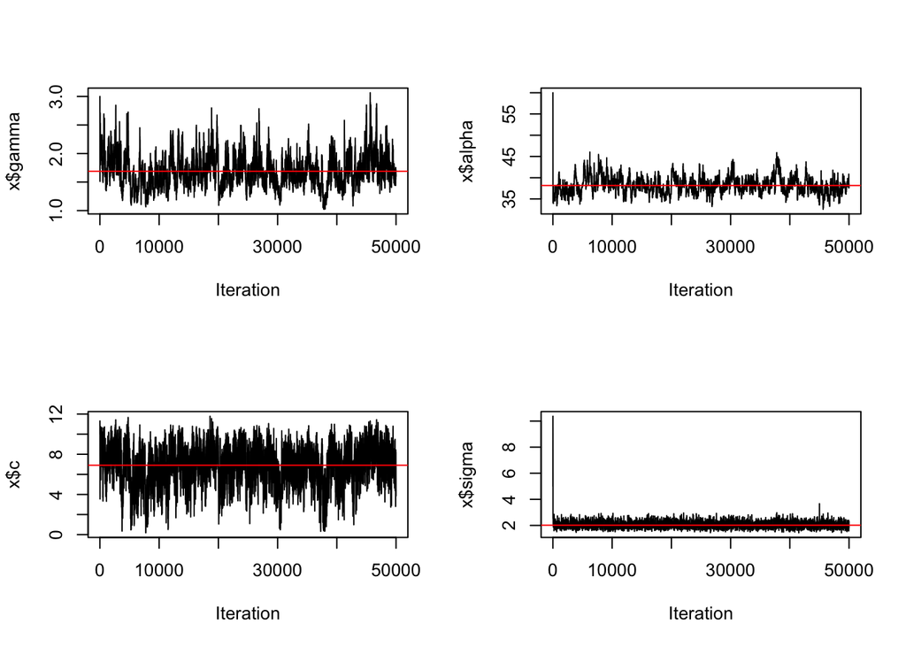

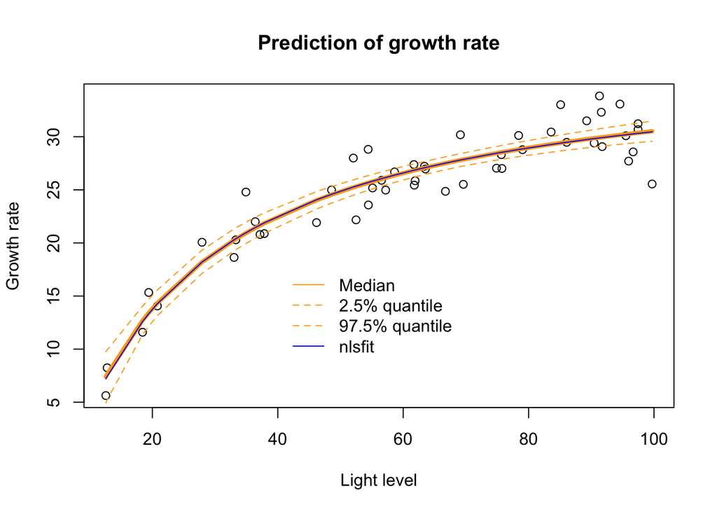

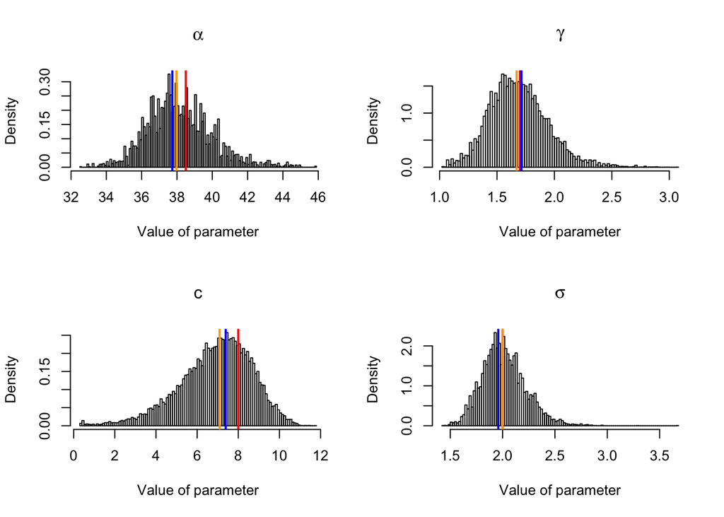

```r
#Set value for burin--the elements that will be discarded
burnin=15000
#Look at the output
do_plots(data=data, x=x, n.iter=n.iter, burnin=burnin)
```